# CO2_Emission

```python
import pandas as pd
import numpy as np
import os
```

## Read data

```python
dateparse = lambda x: pd.to_datetime(x, format='%Y%m', errors = 'coerce')
path= "C:\\Users\\fatemeh\\Desktop\\project\\carbon-emissions\\MER_T12_06.csv"
df = pd.read_csv(path, parse_dates=['YYYYMM'],  date_parser=dateparse)
```

```python
print('Head of dataframe \n %s'%df.head())
print('\n Dataframe iformation \n  %r' %df.info())
```

```
Head of dataframe
        MSN     YYYYMM   Value  Column_Order  \
0  CLEIEUS 1973-01-01  72.076             1
1  CLEIEUS 1973-02-01  64.442             1
2  CLEIEUS 1973-03-01  64.084             1
3  CLEIEUS 1973-04-01  60.842             1
4  CLEIEUS 1973-05-01  61.798             1

                                Description  \
0  Coal Electric Power Sector CO2 Emissions
1  Coal Electric Power Sector CO2 Emissions
2  Coal Electric Power Sector CO2 Emissions
3  Coal Electric Power Sector CO2 Emissions
4  Coal Electric Power Sector CO2 Emissions

                                    Unit
0  Million Metric Tons of Carbon Dioxide
1  Million Metric Tons of Carbon Dioxide
2  Million Metric Tons of Carbon Dioxide
3  Million Metric Tons of Carbon Dioxide
4  Million Metric Tons of Carbon Dioxide
<class 'pandas.core.frame.DataFrame'>
RangeIndex: 5094 entries, 0 to 5093
Data columns (total 6 columns):
MSN             5094 non-null object
YYYYMM          4707 non-null datetime64[ns]
Value           5094 non-null object
Column_Order    5094 non-null int64
Description     5094 non-null object
Unit            5094 non-null object
dtypes: datetime64[ns](1), int64(1), object(4)
memory usage: 238.9+ KB

 Dataframe iformation
  None
```

```python
print(' name of columns in the dataframe are: \n %s. \n Do columns have Null values? \n %s.'%( df.columns, df.isnull().any()))
```

```
 name of columns in the dataframe are:
 Index(['MSN', 'YYYYMM', 'Value', 'Column_Order', 'Description', 'Unit'], dtype='object').
 Do columns have Null values?
 MSN             False
YYYYMM           True
Value           False
Column_Order    False
Description     False
Unit            False
dtype: bool.
```

```python
df['Value'] = pd.to_numeric(df['Value'], errors='coerce')
df = df.dropna()
print('Unique values of Unit column are:\n %s. \n Unique values of Column_Order column are: \n %s. \n Unique values of Description column are: \n %s'%(df['Unit'].unique(), df['Column_Order'].unique(), df['Description'].unique()) )
```

```
Unique values of Unit column are:
 ['Million Metric Tons of Carbon Dioxide'].
 Unique values of Column_Order column are:
 [1 2 3 4 5 6 7 8 9].
 Unique values of Description column are:
 ['Coal Electric Power Sector CO2 Emissions'
 'Natural Gas Electric Power Sector CO2 Emissions'
 'Distillate Fuel, Including Kerosene-Type Jet Fuel, Oil Electric Power Sector CO2 Emissions'
 'Petroleum Coke Electric Power Sector CO2 Emissions'
 'Residual Fuel Oil Electric Power Sector CO2 Emissions'
 'Petroleum Electric Power Sector CO2 Emissions'
 'Geothermal Energy Electric Power Sector CO2 Emissions'
 'Non-Biomass Waste Electric Power Sector CO2 Emissions'
 'Total Energy Electric Power Sector CO2 Emissions']
```

#### function plot_co2emission_year_year_together_bokeh( list of numbers from 1 to 9 for different CO2 emission sources, dataframe) plots CO2 emission from different sources in the same plot using bokeh

The CO2 emission sources for Electric Power are:

1. Coal Electric Power Sector CO2 Emissions
2. Natural Gas Electric Power Sector CO2 Emissions
3. Distillate Fuel, Including Kerosene-Type Jet Fuel, Oil Electric Power Sector CO2 Emissions
4. Petroleum Coke Electric Power Sector CO2 Emissions
5. Residual Fuel Oil Electric Power Sector CO2 Emissions
6. Petroleum Electric Power Sector CO2 Emissions
7. Geothermal Energy Electric Power Sector CO2 Emissions
8. Non-Biomass Waste Electric Power Sector CO2 Emissions
9. Total Energy Electric Power Sector CO2 Emissions

```python
from plot import *
from Trend import *
```

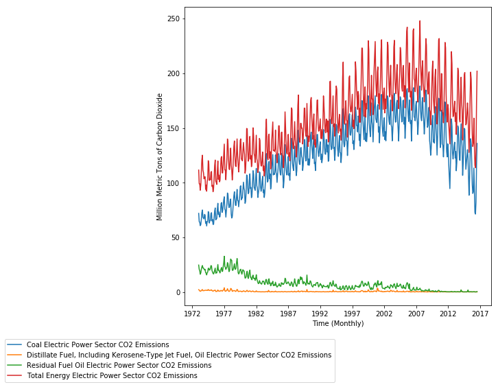

```python
plot_co2emission_year_together_matplotlib([1,3,5,9],df)
```

```python
plot_co2emission_year_bokeh(1,df)
```

[interactive chart not shown]

```python
plot_co2emission_year_together_bokeh([1,2,3,9],df)
```

[interactive chart not shown]

## Sum of CO2 emission per source

using the function plot_CO2_per_source_bar(dataframe) to see the sum of the CO2 resources

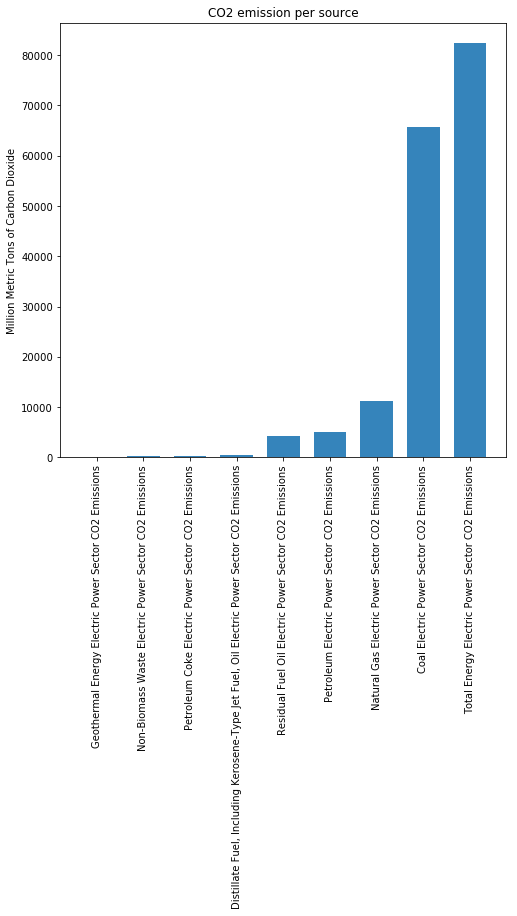

```python
plot_CO2_per_source_bar_matplotlib(df)
```

```python
plot_CO2_per_source_bar_bokeh(df)
```

[interactive chart not shown]

using the function Trend( A number from 1 to 9 for different CO2 emission sources, dataframe, moving average points)

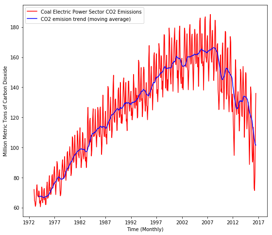

```python
Trend(1 , df, 12)
```

```python
import nbconvert
!jupyter nbconvert --to html CO2_Emission.ipynb
```

```
[NbConvertApp] Converting notebook CO2_Emission.ipynb to html
[NbConvertApp] Writing 409919 bytes to CO2_Emission.html
```